# Homework Project 2

Author

Cheops Steller

## Introduction

In this report, I will explore the trends in the online dating community by analyzing data of anonymized data of user profiles from the dating platform OKCupid. Specifically, I will first investigate the demographics of the user base cross examining gender and ethnicity. Then, I analyzed the relation between education level and people’s expressiveness in terms of how long they wrote in the optional essays for OKCupid’s profiles. Third, the difference of word choices between genders is compared; Last, the top bigrams used by different ethnicities are studied.

```r
file=read.csv("okcupid_profiles.csv")
library(tidyverse)
library(tidytext)
library(kableExtra)
library(babynames)
```

## Data Format

The data has 31 columns, on age, sex, orientation, body type, education, income, job, relationship status, alcohol preference, smoking preference, drug preference, pet, height, last online, ethnicity, location, diet, off spring, religion, zodiac signs, language, and 9 optional personal essays.

## Demographics Visualization

To begin with, let’s explore the demographic composition of the user base of OKCupid. We will analyze the gender ratio when coupled with ethnicity. To do that, I have to first uncouple the people who have more than one ethnicity by unnesting. Then, I graphed the ratio as pie chart and then facet wrapped by ethnicity. From the results, it appeared that as male are on average three fourth of the entire user base, where the ratio more skewed for Indians and Pacific Islanders and less skewed for Asians, Blacks, and Native Americans, and Caucasians.

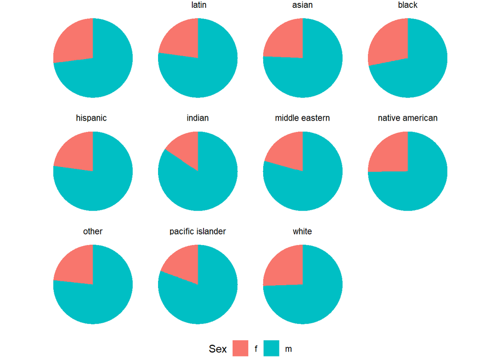

```r
unnested<-file %>%
  separate_rows(ethnicity, sep = ",\\s*") %>%
  separate_rows(ethnicity,sep="/")

ggplot(unnested, aes(x = "", y = sex, fill = sex)) +
  geom_bar(stat = "identity", width = 1) +
  coord_polar(theta = "y") +
  facet_wrap(~ ethnicity, scales = "free", ncol = 4) +
  labs(x = NULL, y = NULL, fill = "Sex") +
  theme_void() +
  theme(legend.position = "bottom")
```

## Analysis of Education Level in Relation to Length of Essays

Here we analyze the relation between education level, and how long people write their essays using the first essay out of nine which most people completed.

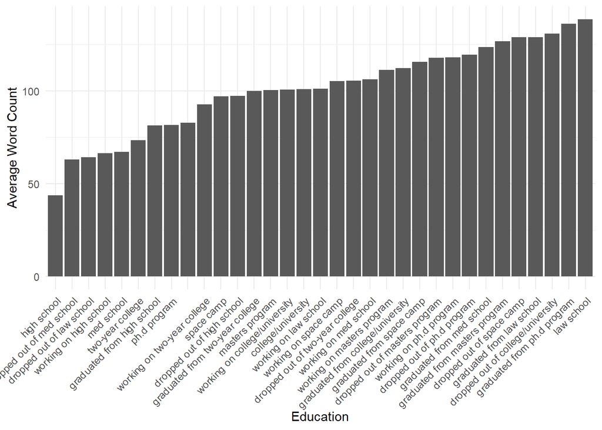

```r
word_counted <- unnested %>%
  mutate(word_count = str_count(essay0, "\\b\\w+\\b"))
edu_word<-word_counted %>%
  group_by(education) %>%
  summarize(mean=mean(word_count)) %>%
  arrange(by=mean)
ggplot(edu_word %>% arrange(desc(mean)), aes(x =reorder( as.factor(education),mean), y = mean)) +
  geom_bar(stat = "identity") +
  labs(x = "Education", y = "Average Word Count") +
  theme_minimal() +
  theme(axis.text.x = element_text(angle = 45, hjust = 1)) +
  theme(legend.position = "none")
```

```r
kable(arrange(edu_word,desc=TRUE))
```

| education | mean |
| --- | --- |
| high school | 43.66912 |
| dropped out of med school | 62.92857 |
| dropped out of law school | 64.32143 |
| working on high school | 66.48026 |
| med school | 67.13333 |
| two-year college | 73.34364 |
| graduated from high school | 81.28726 |
| ph.d program | 81.51429 |
|  | 82.75721 |
| working on two-year college | 92.64538 |
| space camp | 97.13433 |
| dropped out of high school | 97.34641 |
| graduated from two-year college | 99.92785 |
| masters program | 100.36306 |
| working on college/university | 100.76931 |
| college/university | 100.82388 |
| working on law school | 101.08626 |
| working on space camp | 105.34615 |
| dropped out of two-year college | 105.57529 |
| working on med school | 106.16607 |
| working on masters program | 111.20266 |
| graduated from college/university | 112.30727 |
| graduated from space camp | 115.57192 |
| dropped out of masters program | 117.76190 |
| working on ph.d program | 118.09594 |
| dropped out of ph.d program | 119.51479 |
| graduated from med school | 123.49907 |
| graduated from masters program | 126.66260 |
| dropped out of space camp | 128.77902 |
| graduated from law school | 128.89215 |
| dropped out of college/university | 130.69444 |
| graduated from ph.d program | 136.15582 |
| law school | 138.56000 |

## Word Frequency Contrast Between Genders

Now, we compare the use of words between genders in a TF IDF analysis. It turned out that we also need to filter out names along with stop words in the analysis, since many people are introducing themselves by name, which is not a useful indicator for this analysis. Just to clarify: I do not intend to show any words that are inappropriate. The words displayed here to me at least are within tolerable bounds.

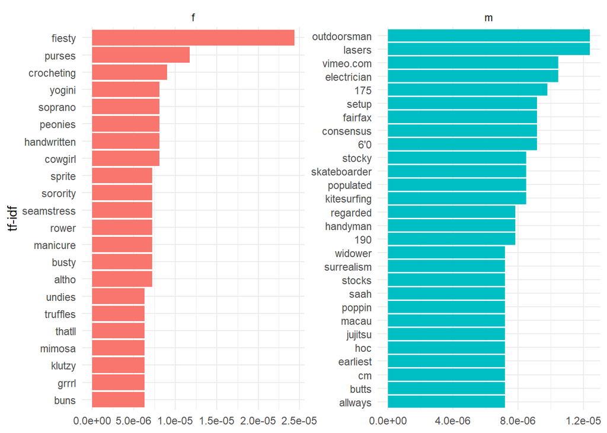

```r
names <- babynames %>%
  select(name) %>%
  distinct() %>%
  pull(name) %>%
  tolower()

essay_freq<-file %>%
  filter(!is.na(essay0) & !is.na(sex))

df_tidy <- essay_freq %>%
  unnest_tokens(word, essay0) %>%
  count(sex, word) %>%
  filter(!word %in% stop_words$word) %>%
  filter(!word %in% names)

idf <- df_tidy %>%
  group_by(sex) %>%
  mutate(term_frequency = n / sum(n)) %>%
  bind_tf_idf(word,sex,n)
idf %>%
  group_by(sex) %>%
  arrange(desc(tf_idf)) %>%
  top_n(20, tf_idf) %>%
  ggplot(aes(x = tf_idf, y = reorder(word, tf_idf), fill = sex)) +
  geom_col(show.legend = FALSE) +
  labs(x = NULL, y = "tf-idf") +
  facet_wrap(~sex, scales = "free") +
  theme_minimal()
```

It is apparent that this essay for most people is a general introduction, with some mentions of hobbies. It is also clear without the labels which one is which, since both columns include many sterotypical words. To see if these patterns continue, let us repeat the same procedure for the second essay.

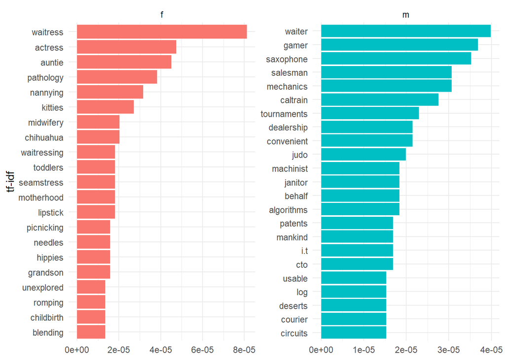

```r
essay_freq2<-essay_freq %>%
  filter(!is.na(essay1))

df_tidy2 <- essay_freq2 %>%
  unnest_tokens(word, essay1) %>%
  count(sex, word) %>%
  filter(!word %in% stop_words$word) %>%
  filter(!word %in% names)

idf2 <- df_tidy2 %>%
  group_by(sex) %>%
  mutate(term_frequency = n / sum(n)) %>%
  bind_tf_idf(word,sex,n)
idf2 %>%
  group_by(sex) %>%
  arrange(desc(tf_idf)) %>%
  top_n(20, tf_idf) %>%
  ggplot(aes(x = tf_idf, y = reorder(word, tf_idf), fill = sex)) +
  geom_col(show.legend = FALSE) +
  labs(x = NULL, y = "tf-idf") +
  facet_wrap(~sex, scales = "free") +
  theme_minimal()
```

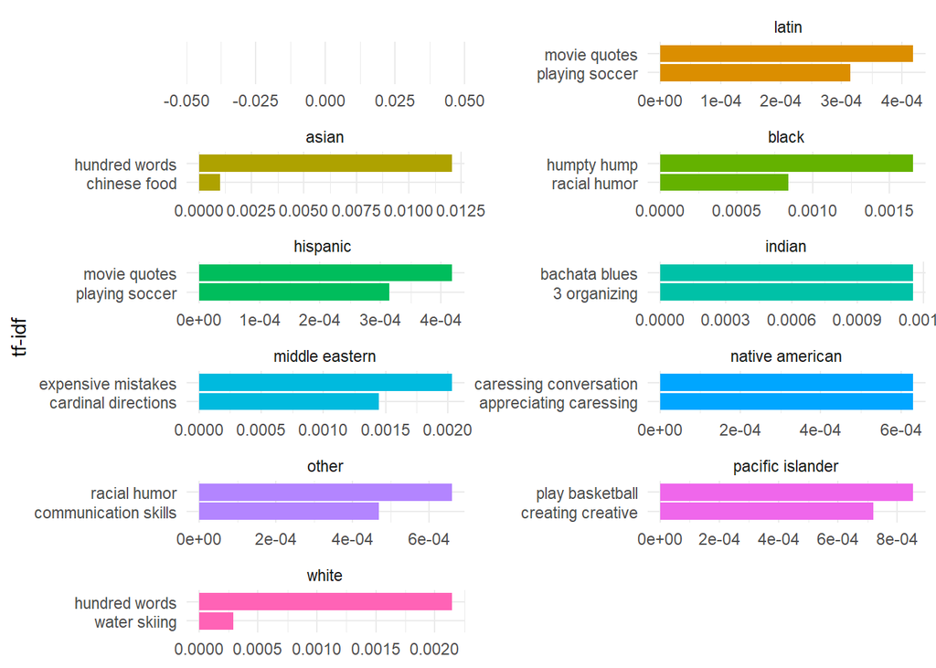

```r
df_bigrams <- unnested %>%
  filter(!is.na(essay2) & !is.na(diet))
bigrams=df_bigrams %>%
  select(ethnicity,essay2)

bigram_tidy <- bigrams %>%
  unnest_tokens(bigram, essay2, token = "ngrams", n = 2) %>%
  group_by(bigram,ethnicity) %>%
  summarize(count = n()) %>%
  ungroup()

bigram_words <- bigram_tidy %>%
  separate(bigram, into = c("word1", "word2"), sep = " ") %>%
  filter(!word1 %in% stop_words$word & !word2 %in% stop_words$word) %>%
  filter(!word1 %in% names & !word2 %in% names)

bigram_without_stopwords <- bigram_words %>%
  unite(bigram, word1, word2, sep = " ")

tf_idf_bigrams <- bigram_without_stopwords %>%
  group_by(ethnicity) %>%
  mutate(term_frequency = count / sum(count)) %>%
  bind_tf_idf(bigram,ethnicity,count)

tf_idf_bigrams %>%
  group_by(ethnicity) %>%
  arrange(desc(tf_idf), .by_group = TRUE) %>%
  mutate(rank = row_number()) %>%  # to break ties
  filter(rank <= 2) %>%
  ggplot(aes(x = tf_idf, y = reorder(bigram, tf_idf), fill = ethnicity)) +
  geom_col(show.legend = FALSE) +
  labs(x = NULL, y = "tf-idf") +
  facet_wrap(~ethnicity, scales = "free",nrow=6) +
  theme_minimal()
```

The results are quite entertaining. For some reason, “racial humor” appeared in two of the top bigrams. Both bigrams for native Americans contains “caressing”, perhaps part of the same phrase being used by many people. “Chinese food” appeared in the Asian category which is expected. I have no idea what the two bigrams for Middle Easterners mean.